# Campaign Manager Add-on

Radiant Logic

# Introduction

## Context

This document describes how to install and use the “Campaign Manager” add-on that allows to orchestrate and manage your access certification campaigns. In addition, this document details the functional coverage of this add-on.

This add-on is available for download in the RadiantOne Identity Analytics Marketplace. website using the following URL: https://marketplace.radiantlogic.com/package/bw_campaignmanager/

This document does not pretend to describe workflows’ creation, configuration, operating principle and more generally to detail iGRC studio’s functionalities.

A full documentation that deals with Workflow is available in the documentation platform using the following URL: https://developer.radiantlogic.com/ia/descartes/igrc-platform/workflow/

And more generally, the full documentation that deals with iGRC studio is available using the following URL: https://developer.radiantlogic.com/ia/descartes/#1

# Campaign manager add-on description

## Add-on functionalities

Through this add-on, you will be able to:

- declare new access certification campaigns
- edit existing access certification campaigns
- launch a new campaign
- follow up the progress of the on-going campaigns
- download the compliance reports

You can plug any kind of access certification campaign in the campaign manager and even configure your own custom campaigns.

Depending on your roles and capabilities you can have a restricted access to the campaign manager:

- all campaigns: full access
- all campaigns: power user (can do everything except killing existing campaigns)
- all campaigns: user (can launch new campaigns and download compliance reports)
- all campaigns: auditor (read only access)
- campaigns owned by the current user: full access
- campaigns owned by the current user: power user (can do everything except killing existing campaigns)
- campaigns owned by the current user: user (can launch new campaigns and download compliance reports)
- campaigns owned by the current user: auditor (read only access)

## Pre-requisites

This add-on is regulariy updated and there can be adherences with features added to the core product. Before installing the facet please check the minimal required version.

Please refer to the [Marketplace](https://marketplace.radiantlogic.com/) for more information

## Add-on content

This add-on contains a workflow file in order to manage campaigns process. This file is available at format `.workflow` and is provided with a `.javascript`

Dashboards are also provided to allow the review requester/owner to configure the review campaign, to get synthesis dashboard on the review configuration. These dashboards are files available at format `.page`.

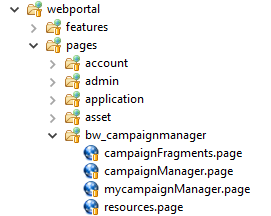

Views are also available to provide data display in dashboards and pages:

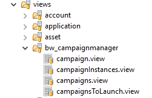

# Campaign manager installation procedure

## Installation procedure

If you don’t have IAP that includes the campaign manager, an add-on is available as a “.facet” format file, which is managed natively by the RadiantOne Identity Analytics studio. It eases installation, updates and remove of the add-on in your Identity Analytics GRC projects.

In order to install the add-on, from the iGRC studio open using the left menu the project configuration window by clicking on “Show project configuration”.

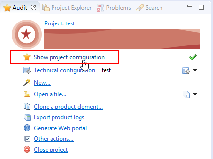

Select the bottom tab “Facets” and click on the “plus” (+) button to add an add-on.

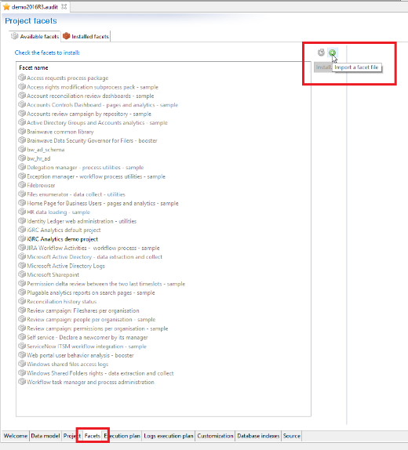

Then select the add-on and click on OK :

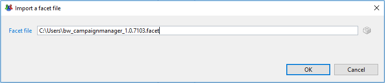

In the tab “Available facets”, select the add-on to install and click on the “install…” button after having previously installed the required dependencies: - The task manager - The process administration add-on:

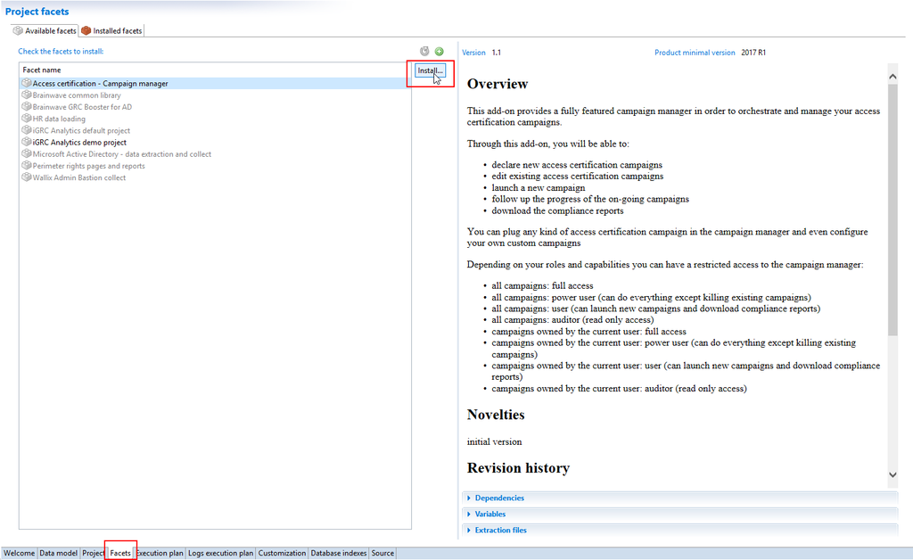

A pop-up window opens, describing all the files that will be installed during the procedure.

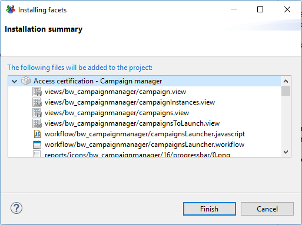

Click on “Finish” to proceed.

## Configuration

Once installed the campaign manager can be accessed through a dedicated menu ‘Review’.

In order to access the campaign manager, the end-user needs to have at least one of the featureset defined in `/webportal/features/bw_campaignmanager/campaignmanager.featuresets`.

No campaigns templates are provided by default, you need to download them from the marketplace. For example: - The identities review per organization: `bw_identities_review_byorg`, http://marketplace.radiantlogic.com/package/bw_identities_review_byorg/

- The permissions review per organization: `bw_permissions_review_byorg`, http://marketplace.radiantlogic.com/package/bw_permissions_review_byorg/

In order to launch automatically new scheduled campaigns, you need to run a technical workflow on a regular basis.

It’s ID is campaignsLauncher. You can launch it in batch mode thanks to the script `igrc_workflow.cmd`. It is recommended to launch it on a daily basis. Then automatically, depending on the campaign frequency configuration, the reviews will be automatically launched.

## Add-on update and remove procedures

To update the add-on, follow the same procedure as previously to import the last version of the add-on:

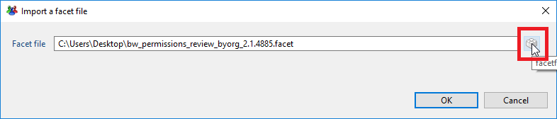

Then from the “Installed facets” tab, select the add-on “Access certification - Campaign manager” and click on “Upgrade…” to upgrade the add-on.

[figure not shown]

A pop-up window describes the files that will be upgraded during the procedure. By selecting “Keep replaced files…” the replaced files are kept by renaming as `.old`. Click on “Finish” to launch the upgrade.

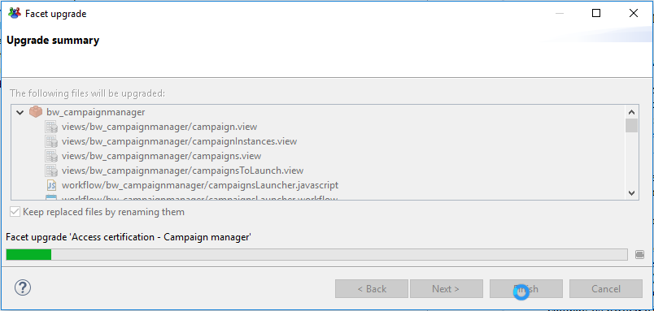

To uninstall the add-on, select it in the list then click on “Delete…”.

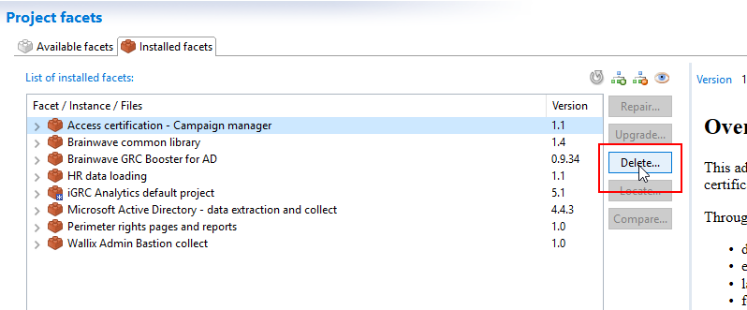

A “confirm deletion” pop-up window opens. Click on “Finish” to execute the deletion.

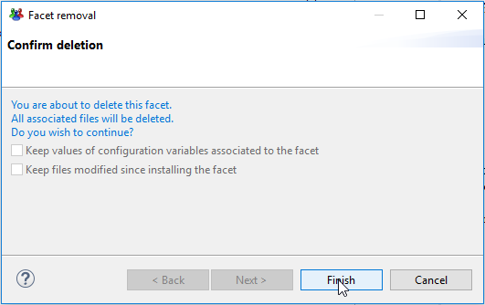

Note that after having installed or updated an add-on of type workflow, you should restart the iGRC studio and the tomcat service to take into account the changes.

# Campaign manager functional coverage

## Campaign manager profiles and roles

Featuresets are used to configure access to the campaign manager interfaces. By default, the role “user” has access to all features with the featureset `bwcm_all` that means that by default all users have access to all campaign manager interfaces and features.

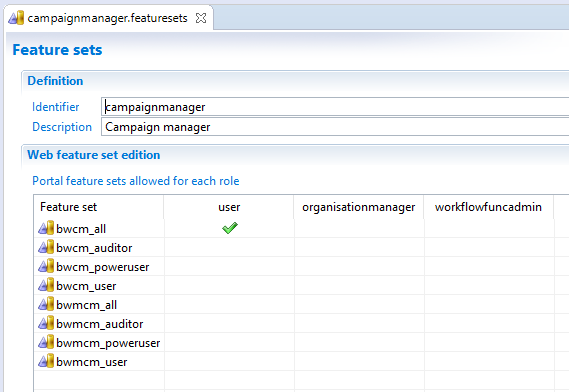

The following featuresets are available: - `bwcm_all`: Campaign manager - All access rights - `bwcm_auditor`: Campaign manager auditor - `bwcm_poweruser`: Campaign manager power user - `bwcm_user`: Campaign manager user (can launch campaign instances) - `bwmcm_all`: My campaign manager - All access rights - `bwmcm_auditor`: My campaign manager auditor - `bwmcm_poweruser`: My campaign manager power user - `bwmcm_user`: My campaign manager user (can launch campaign instances)

These featuresets are associated to two main pages, “Campaign manager” where you can create, monitor and administrate all the reviews and “My campaigns” where you can create, monitor and administrate only reviews you own.

By default, these two pages are available under the ‘Category’ menu “Review” from the web portal:

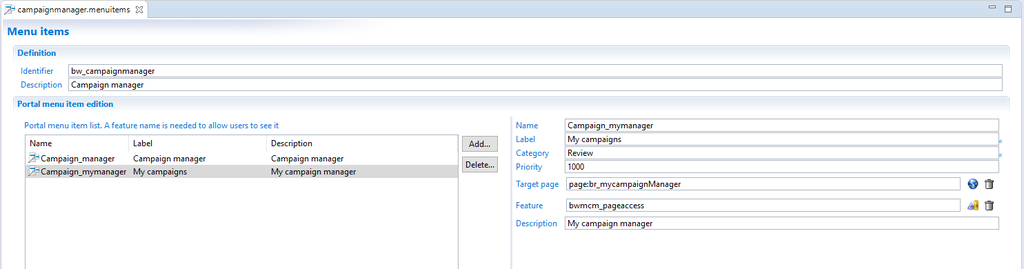

Note that the access to reviews and remediation workflows is then depending on the configuration of the featuresets and roles provided in these additional add-ons.

Here is a full description of the features available in the campaign manager:

- bwcm_canaddcampaign: Can add a new campaign (`bwcm_all`, `bwcm_poweruser`)
- bwcm_caneditcampaign: Can edit an existing campaign (`bwcm_all`, `bwcm_poweruser`)
- bwcm_canviewcampaign: Can view an existing campaign configuration (`bwcm_all`, `bwcm_poweruser`, `bwcm_user`)
- bwcm_cankillcampaign: Can kill a running campaign instance (`bwcm_all`)
- bwcm_candownloadcompliancereport: Can download the compliance report of an existing campaign finalized instance (`bwcm_all`, `bwcm_poweruser`, `bwcm_user`, `bwcm_auditor`)
- bwcm_canlaunchcampaign: Can launch a new campaign (`bwcm_all`, `bwcm_poweruser`, `bwcm_user`)
- bwcm_canenablecampaign: Can enable a disabled campaign (`bwcm_all`)
- bwcm_candisablecampaign: Can disable a campaign (`bwcm_all`, `bwcm_poweruser`)
- bwcm_canjumptoreportpage: Can jump to the report page of a finalized campaign (`bwcm_all`, `bwcm_poweruser`, `bwcm_user`)
- bwcm_canjumptostatuspage: Can jump to the status page of a running campaign (`bwcm_all`, `bwcm_poweruser`, `bwcm_user`)
- bwcm_pageaccess: Can access to the campaign manager page (`bwcm_all`, `bwcm_poweruser`, `bwcm_user`, `bwcm_auditor`)
- bwcm_canviewcampaignstatus: Can access to the campaign static status page (`bwcm_all`, `bwcm_poweruser`, `bwcm_user`)
- bwmcm_canaddcampaign: Can add a new campaign in my campaign manager (`bwmcm_all`, `bwmcm_poweruser`)
- bwmcm_caneditcampaign: Can edit an existing campaign in my campaign manager (`bwmcm_all`, `bwmcm_poweruser`)
- bwmcm_canviewcampaign: Can view an existing campaign configuration in my campaign manager (`bwmcm_all`, `bwmcm_poweruser`, `bwmcm_user`)
- bwmcm_cankillcampaign: Can kill a running campaign instance in my campaign manager (`bwmcm_all`)
- bwmcm_candownloadcompliancereport: Can download the compliance report of an existing campaign finalized instance in my campaign manager (`bwmcm_all`, `bwmcm_poweruser`, `bwmcm_user`, `bwmcm_auditor`)
- bwmcm_canlaunchcampaign: Can launch a new campaign instance in my campaign manager (`bwmcm_all`, `bwmcm_poweruser`, `bwmcm_user`)
- bwmcm_canenablecampaign: Can enable a disabled campaign in my campaign manager (`bwmcm_all`)
- bwmcm_candisablecampaign: Can disable a campaign in my campaign manager (`bwmcm_all`, `bwmcm_poweruser`)
- bwmcm_canjumptoreportpage: Can jump to the report page of a finalized campaign in my campaign manager (`bwmcm_all`, `bwmcm_poweruser`, `bwmcm_user`)
- bwmcm_canjumptostatuspage: Can jump to the status page of a running campaign in my campaign manager (`bwmcm_all`, `bwmcm_poweruser`, `bwmcm_user`)
- bwmcm_pageaccess: Can access to the my campaign manager page (`bwmcm_all`, `bwmcm_poweruser`, `bwmcm_user`, `bwmcm_auditor`)
- bwmcm_canviewcampaignstatus: Can access to the my campaign static status page (`bwmcm_all`, `bwmcm_poweruser`, `bwmcm_user`)

## Functionalities related to campaign management

From the main page “Campaign Manager”, you are able to configure any of your campaign that you have installed in your RadiantOne Identity Analytics project. To do so, click on “Add a new campaign”.

[figure not shown]

Home page of the campaign manager

Depending on your role and perimeter, you will find a list of campaigns that you can start to configure.

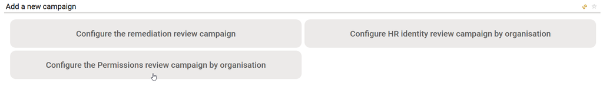

Add a new campaign

Click on the related button to configure your review or remediation process.

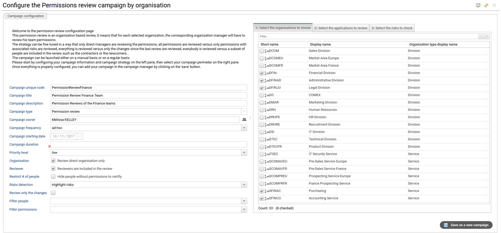

Example of campaign configuration page: Permissions review campaign

In the configuration page of your process, you are able to select the frequency of your campaign, to automate the launch of reviews or remediation. Note that to be effective, you need to schedule the script `igrc_workflow`.cmd on a daily basis with the process name “campaignsLauncher”.

You can also execute a campaign at any time by using the option “ad-hoc”.

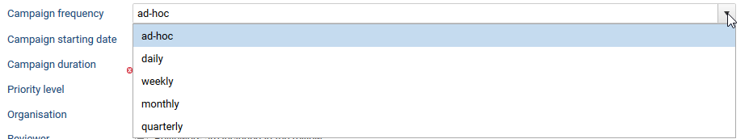

Campaign frequency setup

Once configured, the campaign is added to the list of available campaigns in the main page, in the table on the left.

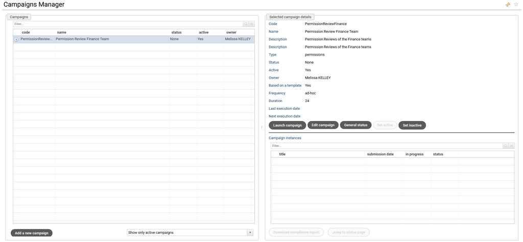

Campaigns manager page

You can at any time filter the campaigns you need to display, by using the “Filter…” at the top of the table or by choosing to show only active, inactive or all campaigns using the combo box at the bottom of the table.

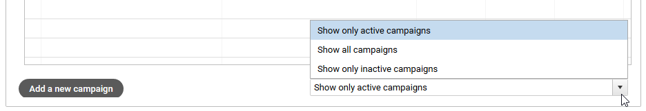

Filtering campaigns by active status

By selecting a campaign, you can:

- Click on “Launch campaign” to manually launch the selected campaign manually

Note: To use this feature, you need `bwcm_canlaunchcampaign` feature, or by default `bwcm_all`, `bwcm_poweruser` and `bwcm_user` featuresets.

- Click on “Edit campaign” to view and change the configuration of the selected campaign.

- Click on “General status” to view pages presenting a full status of all your campaigns and an overview on the statistics regarding campaigns completion. These pages are not available by default and need to be created after add-on installation.

Note: To use this feature, you need `bwcm_canviewcampaignstatus` feature, or by default `bwcm_all`, `bwcm_poweruser`" and `bwcm_user` featuresets.

- Click on “Set active” to re-activate the selected campaign which has been inactivated.

Note: To use this feature, you need `bwcm_canenablecampaign` feature, or by default `bwcm_all` featureset.

- Click on “Set inactive”: to inactivate the selected campaign.

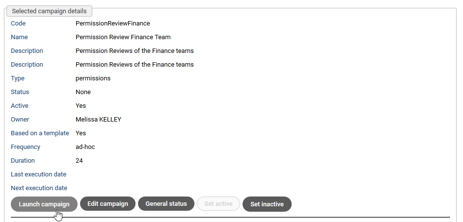

Selected campaign details

When launching a campaign, a confirmation popup appears. Select “OK” to start the campaign. Note that depending on your process configuration, a series of email can be launched by the notification process.

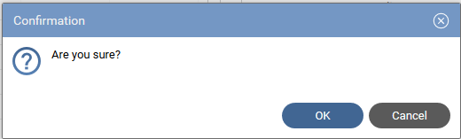

Once confirmed, the campaign is added to the ongoing campaign instances list, at the bottom right of the dashboard.

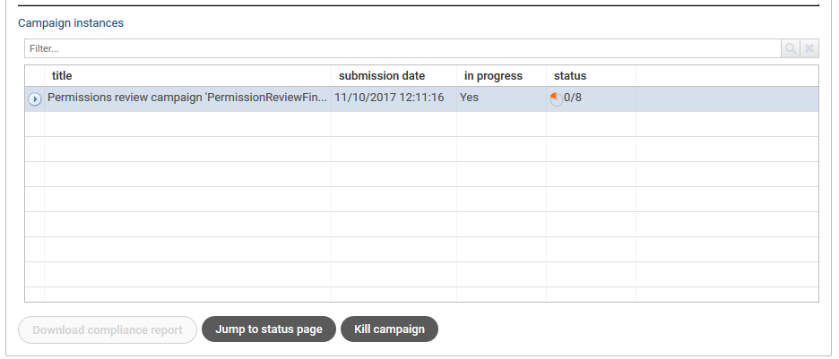

On-going and completed campaigns list

When selecting an on-going or completed campaign, you are able to:

- Download compliance report: When the campaign has been completed, you are able to download the compliance report in PDF format.

Note: To use this feature, you need `bwcm_candownloadcompliancereport` feature, or by default `bwcm_all`, `bwcm_poweruser`, `bwcm_user` and `bwcm_auditor` featuresets.

- Jump to status page: Go to the status page to follow-up the status of your reviews/remediations completion, and check statistics.
- Kill campaign: Kill an ongoing campaign. When doing so, the campaign is aborted and the related tasks are removed from all actors’ dashboards.

Note: To use this feature, you need `bwcm_cankillcampaign` feature, or by default `bwcm_all` featureset.

When clicking on “Jump to status page”, you reach the status dashboard related to the campaign you configured. This dashboard allows to follow-up the completion of all the tasks generated by the campaign.

In the following screenshots, the “Permission review” campaign status page is used as example.

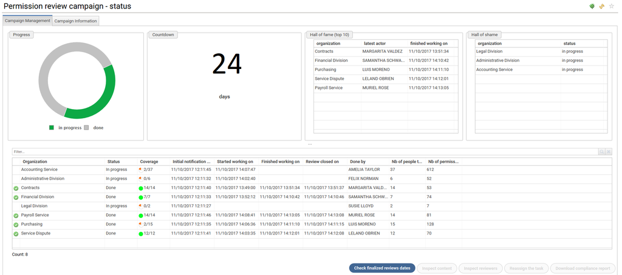

Campaign status page of the Permission review add-on

By clicking on the tab “Campaign Information”, you are able to view the configuration of the launched campaign.

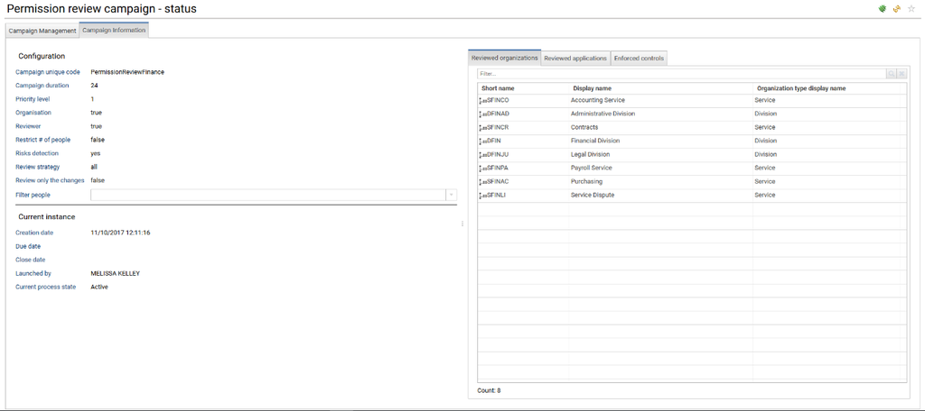

Campaign configuration tab

By selecting “check finalized reviews dates”, you are able to display a Gantt diagram presenting the time period for completing the tasks such as reviews by each reviewer:

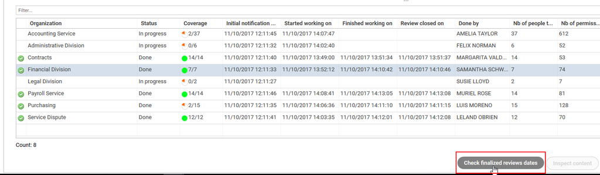

Campaign status with dates check options

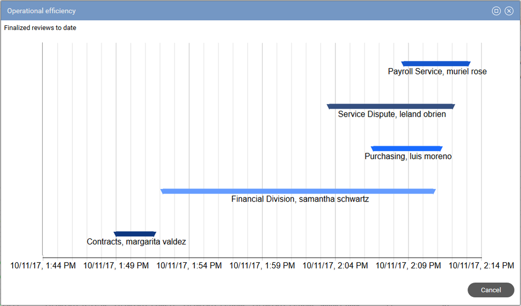

Time period for completing the reviews by each reviewer

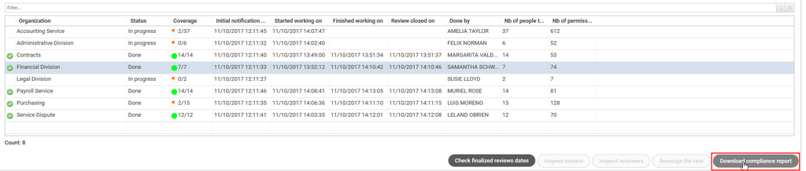

Download compliance report

For each completed permission review task, click on “download compliance report” in order to retrieve the PDF compliance report regarding the selected task:

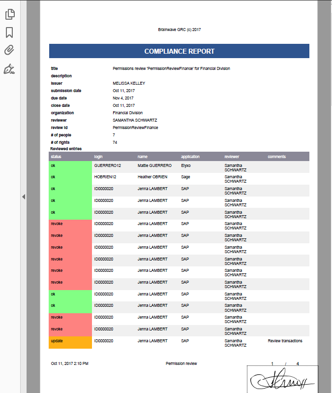

PDF compliance report

For each on-going permission review task, you are able to: - Inspect content: View in “read only” mode the reviewer dashboard, to follow-up the completion.